# PML Assignment Week4

mahajang

April 2, 2016

### Inroduction :

#### Using devices such as Jawbone Up, Nike FuelBand, and Fitbit it is now possible to collect a large amount of data about personal activity relatively inexpensively. These type of devices are part of the quantified self movement - a group of enthusiasts who take measurements about themselves regularly to improve their health, to find patterns in their behavior, or because they are tech geeks. One thing that people regularly do is quantify how much of a particular activity they do, but they rarely quantify how well they do it. In this project, your goal will be to use data from accelerometers on the belt, forearm, arm, and dumbell of 6 participants. They were asked to perform barbell lifts correctly and incorrectly in 5 different ways.

### Data Loading:

```r
library(dplyr)
```

```r
library(ggplot2)
library(lubridate)
library(caret)
library(randomForest)
library(rpart)
library(rpart.plot)
library(corrplot)

data.train<- read.csv("C:/1. HP- Work files/HP WORK 1st Feb 2015/COURSERA_COURSES/8. Machine_Learning/Week4_Assignment/pml-training.csv", na.strings = c("NA", "#DIV/0!", ""))

data.test<- read.csv("C:/1. HP- Work files/HP WORK 1st Feb 2015/COURSERA_COURSES/8. Machine_Learning/Week4_Assignment/pml-testing.csv", na.strings = c("NA", "#DIV/0!", ""))
```

### Data Understandaing:

```r
dim(data.train)
```

```
## [1] 19622   160
```

```r
glimpse(data.train)
```

```
## Observations: 19,622
## Variables: 160
## $ X                        (int) 1, 2, 3, 4, 5, 6, 7, 8, 9, 10, 11, 12...
## $ user_name                (fctr) carlitos, carlitos, carlitos, carlit...
## $ raw_timestamp_part_1     (int) 1323084231, 1323084231, 1323084231, 1...
## $ raw_timestamp_part_2     (int) 788290, 808298, 820366, 120339, 19632...
## $ cvtd_timestamp           (fctr) 5/12/2011 11:23, 5/12/2011 11:23, 5/...
## $ new_window               (fctr) no, no, no, no, no, no, no, no, no, ...
## $ num_window               (int) 11, 11, 11, 12, 12, 12, 12, 12, 12, 1...
## $ roll_belt                (dbl) 1.41, 1.41, 1.42, 1.48, 1.48, 1.45, 1...
## $ pitch_belt               (dbl) 8.07, 8.07, 8.07, 8.05, 8.07, 8.06, 8...
## $ yaw_belt                 (dbl) -94.4, -94.4, -94.4, -94.4, -94.4, -9...
## $ total_accel_belt         (int) 3, 3, 3, 3, 3, 3, 3, 3, 3, 3, 3, 3, 3...
## $ kurtosis_roll_belt       (dbl) NA, NA, NA, NA, NA, NA, NA, NA, NA, N...
## $ kurtosis_picth_belt      (dbl) NA, NA, NA, NA, NA, NA, NA, NA, NA, N...
```

[output cut: 147 more lines]

### Data Transformation : Convert date and add new variable (Day)

```r
data.train$cvtd_timestamp<- as.Date(data.train$cvtd_timestamp, format = "%m/%d/%Y %H:%M")
data.train$Day<-factor(weekdays(data.train$cvtd_timestamp)) #Add day variable
```

### Exploratory Data Analysis

```r
table(data.train$classe)
```

```
##
##    A    B    C    D    E
## 5580 3797 3422 3216 3607
```

```r
prop.table(table(data.train$classe))
```

```
##
##         A         B         C         D         E
## 0.2843747 0.1935073 0.1743961 0.1638977 0.1838243
```

```r
prop.table(table(data.train$user_name))
```

```
##
##    adelmo  carlitos   charles    eurico    jeremy     pedro
## 0.1983488 0.1585975 0.1802059 0.1564570 0.1733768 0.1330140
```

```r
prop.table(table(data.train$user_name,data.train$classe),1)
```

```
##
##                    A         B         C         D         E
##   adelmo   0.2993320 0.1993834 0.1927030 0.1323227 0.1762590
##   carlitos 0.2679949 0.2217224 0.1584190 0.1561697 0.1956941
##   charles  0.2542421 0.2106900 0.1524321 0.1815611 0.2010747
##   eurico   0.2817590 0.1928339 0.1592834 0.1895765 0.1765472
##   jeremy   0.3459730 0.1437390 0.1916520 0.1534392 0.1651969
##   pedro    0.2452107 0.1934866 0.1911877 0.1796935 0.1904215
```

```r
prop.table(table(data.train$user_name,data.train$classe),2)
```

```
##
##                    A         B         C         D         E
##   adelmo   0.2087814 0.2043719 0.2191701 0.1601368 0.1901857
##   carlitos 0.1494624 0.1817224 0.1440678 0.1511194 0.1688384
##   charles  0.1611111 0.1962075 0.1575102 0.1996269 0.1971167
##   eurico   0.1550179 0.1559126 0.1428989 0.1809701 0.1502634
##   jeremy   0.2109319 0.1287859 0.1905319 0.1623134 0.1558082
##   pedro    0.1146953 0.1329997 0.1458212 0.1458333 0.1377876
```

```r
prop.table(table(data.train$classe, data.train$Day),1)
```

```
##
##      Saturday  Thursday
##   A 0.5833804 0.4166196
##   B 0.5600147 0.4399853
##   C 0.5651030 0.4348970
##   D 0.5478220 0.4521780
##   E 0.5581302 0.4418698
```

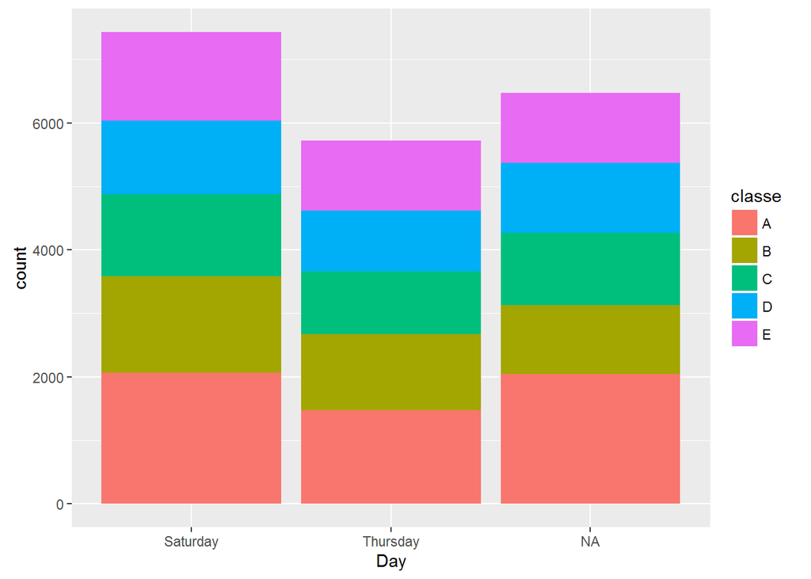

```r
qplot(x=Day, fill=classe, data = data.train)
```